# hw2-irene-liang

# C) Main Analysis (To be reported)

```r
# Focus on the 2012 Atlantic hurricane season (i.e. year 2012)
ibtracs_2012 <- ibtracs %>% filter(SEASON == 2012) # 1267 rows
```

## C.1) Seasonal Statistics

### C1.a) total number of depressions (i.e. both named and unnamed storms)

The total number of depressions (both named and unnamed storms) is 19.

```r
# Check whether all observations are named:
dep_2012 <- ibtracs_2012 %>% filter(WMO_WIND <= 33)
dep_2012$IF_UNNAMED <- dep_2012$NAME == 'NO_NAMED'
total_depressions_2012 <- dep_2012 %>%
  distinct(SID, IF_UNNAMED) %>%
  group_by(IF_UNNAMED) %>%
  count()
total_depressions_2012 # We see that all 19 depressions are named
```

```
## # A tibble: 1 × 2
## # Groups:   IF_UNNAMED [1]
##   IF_UNNAMED     n
##   <lgl>      <int>
## 1 FALSE         19
```

```r
total_depressions_2012$n # Total number of depressions is 19
```

```
## [1] 19
```

```r
# Use `ibtracs_2012` that contains only year 2012's data and filter so that it contains only depressions (defined to have a maximum sustained winds of 33 knots or less). Then, add an indicator column "IF_UNNAMED" for whether the observation is named. Lastly, count the frequency of the unique total number of depressions based on SID.
```

### C1.b) number of named storms

There are 19 named storms, which means that all depressions in 2012 developed into a tropical storm.

```r
storms_2012 <- ibtracs_2012 %>%
  filter(WMO_WIND >= 34 & WMO_WIND <= 63) # storms have maximum sustained winds of 34 to 63 knots

named_storms_2012 <- storms_2012 %>%
  filter(NAME != 'NOT_NAMED') %>%
  select(SID) %>% unique() %>% count()
named_storms_2012
```

```
##    n
## 1 19
```

### C1.c) number of hurricanes, and their names

There were 10 hurricanes, namely, CHRIS, ERNESTO, GORDON, ISAAC, LESLIE, KIRK, MICHAEL, NADINE, RAFAEL, and SANDY.

```r
num_hur_2012 <- ibtracs_2012 %>%
  filter(WMO_WIND >= 64) %>% select(SID) %>% unique() %>% count()
num_hur_2012 # There are 10 hurricanes, which are defined to have a maximum sustained winds of 64 knots or higher
```

```
##    n
## 1 10
```

```r
name_hur_2012 <- ibtracs_2012 %>%
  filter(WMO_WIND >= 64) %>% select(NAME) %>% unique()
name_hur_2012 # This gives the names of the ten hurricanes, which are CHRIS, ERNESTO, GORDON, ISAAC, LESLIE, KIRK, MICHAEL, NADINE, RAFAEL, and SANDY.
```

```
##        NAME
## 1     CHRIS
## 4   ERNESTO
## 10   GORDON
## 20    ISAAC
## 27   LESLIE
## 42     KIRK
## 50  MICHAEL
## 71   NADINE
## 92   RAFAEL
## 104   SANDY
```

### C1.d) number of major hurricanes, and their names

There were two major hurricanes, namely, MICHAEL and SANDY.

```r
num_major_hur_2012 <- ibtracs_2012 %>%
  filter(WMO_WIND >= 96) %>%
  select(SID) %>% unique() %>% count()
num_major_hur_2012 # Using similar code logic as the previous parts, filter out the 2012 data so that it only contains rows of major hurricanes, which are defined to have a maximum sustained winds of 96 knots or higher. From the analysis, we conclude that there were 2 major hurricanes.
```

```
##   n
## 1 2
```

```r
name_major_hur_2012 <- ibtracs_2012 %>%
  filter(WMO_WIND >= 96) %>% select(NAME) %>% unique()
name_major_hur_2012 # the two major hurricanes are MICHAEL and SANDY
```

```
##      NAME
## 1 MICHAEL
## 2   SANDY
```

### C1.e) date of the first system formed, and its name

The first system formed in 2012 was ALBERTO on the date 2012-05-19. This makes sense since the first storm of the year will always have a name that starts with the letter “A”.

```r
iso_asc_sorted2012 <- ibtracs_2012 %>% select(NAME, ISO_TIME) %>% arrange(ISO_TIME) # Create a new table with two columns: NAME and ISO_TIME, sorted by ISO_TIME in ascending order.
iso_asc_sorted2012$DATE <- lubridate::date(iso_asc_sorted2012$ISO_TIME) # Extract the date from "ISO_TIME", and add a new column with the date information.

iso_asc_sorted2012_date <- iso_asc_sorted2012 %>% select(NAME, DATE) # Since the question only asks for the date and name of the first system formed, we subset the data with the columns of interest.

form_date_name <- iso_asc_sorted2012_date[1,] # Take the first row, which contains information about the system formed.
form_date_name # ALBERTO is the first system formed, on the date 2012-05-19. This makes sense since the first storm of the year will always have a name that starts with the letter "A".
```

```
##      NAME       DATE
## 1 ALBERTO 2012-05-19
```

### C1.f) date of the last system dissipated, and its name

The last system dissipated in 2012 was SANDY on the date 2012-10-31.

```r
iso_des_sorted2012 <- ibtracs_2012 %>% select(NAME, ISO_TIME) %>% arrange(desc(ISO_TIME)) # Create a new table with two columns: NAME and ISO_TIME, sorted by ISO_TIME in descending order.
iso_des_sorted2012$DATE <- lubridate::date(iso_des_sorted2012$ISO_TIME) # Extract the date from "ISO_TIME", and add a new column with the date information.

iso_des_sorted2012_date <- iso_des_sorted2012 %>% select(NAME, DATE) # Since the question only asks for the date and name of the last system dissipated, we subset the data with the columns of interest.

diss_date_name <- iso_des_sorted2012_date[1,] # Take the first row, which contains information about the system dissipated
diss_date_name # SANDY is the last system dissipated, on the date 2012-10-31
```

```
##    NAME       DATE
## 1 SANDY 2012-10-31
```

## C.2) Statistics of Strongest Storm

### C2.a) Name of strongest storm

The name of the strongest storm in 2012 is SANDY.

```r
storms_2012_wind_pres <- ibtracs_2012 %>% arrange(desc(WMO_WIND), WMO_PRES) # Use the ibtracs_2012 data, which includes only data from 2012. Sort it by descending "WMO_WIND" (higher maximum sustained wind speed implies stronger storm) and ascending "WMO_PRES" (the lower the barometric pressure, the more intense the storm).
storms_2012_wind_pres[1, "NAME"] # The name of the strongest storm is SANDY
```

```
## [1] "SANDY"
```

### C2.b) Its maximum wind speed

In 2012, the strongest storm, SANDY, has a maximum wind speed of 100 knots.

```r
storms_2012_wind <- ibtracs_2012 %>%
  filter(NAME == "SANDY") %>%
  arrange(desc(WMO_WIND)) # Filter `ibtracs_2012` so that it only includes the strongest storm, "SANDY". Then, sort by WMO_WIND in descending order so that the first row will contain data of the maximum wind speed.
storms_2012_wind[1, "WMO_WIND"] # The strongest storm, SANDY, has a maximum wind speed of 100 knots
```

```
## [1] 100
```

### C2.c) Its lowest pressure

In 2012, the strongest storm, SANDY, has a lowest pressure of 940mb.

```r
storms_2012_pres <- ibtracs_2012 %>%
  filter(NAME == "SANDY") %>%
  arrange(WMO_PRES) # Filter `ibtracs_2012` so that it only includes the strongest storm, "SANDY". Then, sort by "WMO_PRES" in ascending order so that the first row will contain data of the lowest pressure.

storms_2012_pres[1, "WMO_PRES"] # The strongest storm, SANDY, has a lowest pressure of 940mb
```

```
## [1] 940
```

## C.3) Historical Comparison: In the analyzed “historical” period (years 1970-2021)

```r
historical_period <- ibtracs %>% filter(SEASON >= 1970 & SEASON <= 2021) # Subset of ibtracs with only data of historical period (years 1970-2021)
```

### C3.a) Compared to the “historical” average number of named storms, was the 2012 season an above-average, a below-average, or an average season?

Compared to the “historical” average number of named storms, since there were 19 named storms in 2012 and an average of 12.11538 named storms over the historical period, we can conclude that the 2012 season was an above-average season.

```r
named_storms_historical <- historical_period %>%
  filter(NAME != 'NOT_NAMED') %>%
  group_by(SEASON) %>%
  distinct(NAME) %>%
  count(SEASON) # Filter `historical_period` by keeping only named storms, and counting the frequency of the total number of unique historical storms

avg_named_storms_historical <- named_storms_historical %>%
  ungroup() %>%
  summarise(mean(n)) %>%
  as.numeric()
avg_named_storms_historical # There are 52 years over the historical period 1970-2021, so we take the average to get that there were around 12.11538 named storms on average over the historical period.
```

```
## [1] 12.11538
```

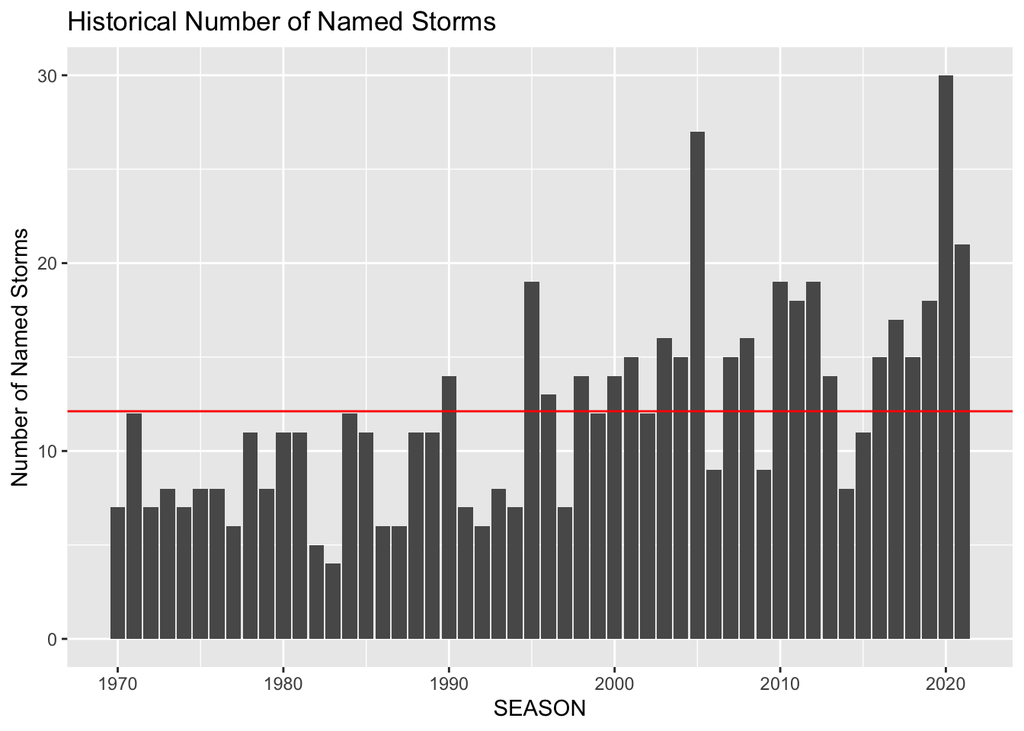

```r
# Visual display: barchart of named storms frequencies for each `SEASON`
ggplot(named_storms_historical, aes(x=SEASON, y=n)) +
  geom_col() +
  geom_hline(yintercept = avg_named_storms_historical, color="red") +
  labs(y= "Number of Named Storms", x = "SEASON") +
  ggtitle("Historical Number of Named Storms")
```

```r
# Since there were 19 named storms in 2012, and an average of 12.11538 named storms over the historical period, we can conclude that the 2012 season was an above-average season.
```

### C3.b) Compared to the “historical” average number of hurricanes, was the 2012 season an above-average, a below-average, or an average season?

Compared to the “historical” average number of hurricanes, since there were 10 hurricanes in 2012 and an average of 6.538462 hurricanes over the historical period, we can conclude that the 2012 season was an above-average season.

```r
num_hur_historical <- historical_period %>%
  filter(WMO_WIND >= 64) %>%
  group_by(SEASON) %>%
  distinct(SID) %>%
  count(SEASON) # Filter `historical_period` by keeping only hurricanes, which are defined to have a maximum sustained winds of 64 knots or higher. Further, count the frequency of the number of hurricanes for each unique SID.

avg_hurricanes_historical <- num_hur_historical %>%
  ungroup() %>%
  summarise(mean(n)) %>%
  as.numeric()
avg_hurricanes_historical # Take the average yielding around 6.538462 hurricanes on average over the historical period
```

```
## [1] 6.538462
```

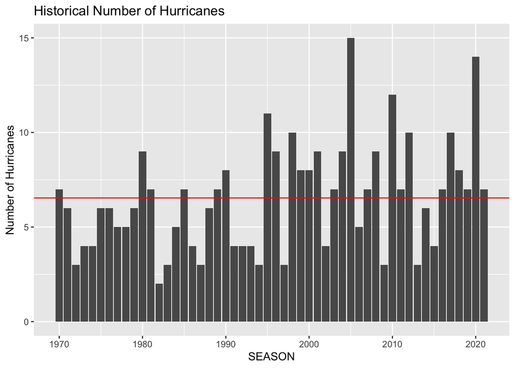

```r
# Visual display: barchart of hurricane frequency for each `SEASON`
ggplot(num_hur_historical, aes(x=SEASON, y=n)) +
  geom_col() +
  geom_hline(yintercept = avg_hurricanes_historical, color = "red") +
  labs(y= "Number of Hurricanes", x = "SEASON") +
  ggtitle("Historical Number of Hurricanes")
```

```r
# Since there were 10 hurricanes in 2012, and an average of 6.538462 hurricanes over the historical period, we can conclude that the 2012 season was an above-average season.
```

### C3.c) Compared to the “historical” average of maximum winds, was the 2012 season an above-average, a below-average, or an average season?

Compared to the “historical” average of maximum winds, since the maximum wind for 2012 was 100 knots while the historical average of maximum winds was around 126.3462 knots, we can conclude that the 2012 season was a below-average season.

```r
max_wind_historical <- historical_period %>%
  replace_na(list(WMO_WIND = 0)) %>%
  group_by(SEASON) %>%
  summarise(
    max = max(WMO_WIND, na.rm = TRUE)) # Replace all empty cells of "WMO_WIND" with 0, group by "SEASON", and for each "SEASON", choose the maximum "WMO_WIND"

avgmax_wind_historical <- max_wind_historical %>%
  ungroup() %>%
  summarise(mean(max)) %>%
  as.numeric()
avgmax_wind_historical
```

```
## [1] 126.3462
```

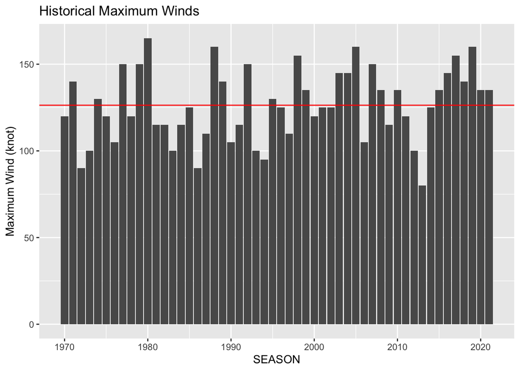

```r
# Historical average of maximum winds is 126.3462 knots

# Visual display: barchart of named storms frequencies for each `SEASON`
ggplot(max_wind_historical, aes(x=SEASON, y=max)) +
  geom_col() +
  geom_hline(yintercept = avgmax_wind_historical, color = "red") +
  labs(y= "Maximum Wind (knot)", x = "SEASON") +
  ggtitle("Historical Maximum Winds")
```

```r
# Since the maximum wind for 2012 was 100 knots while the historical average of maximum winds was around 126.3462 knots, we can conclude that the 2012 season was a below-average season.
```

## C.4) Season Summary Map

### C4.a) Obtain a graph to map the location (and trajectories) of the storms. The background of your map does not have to be identical to the above image. The important thing is to have a map where the viewer can distinguish the Atlantic ocean, the continents, and of course the individual storms.

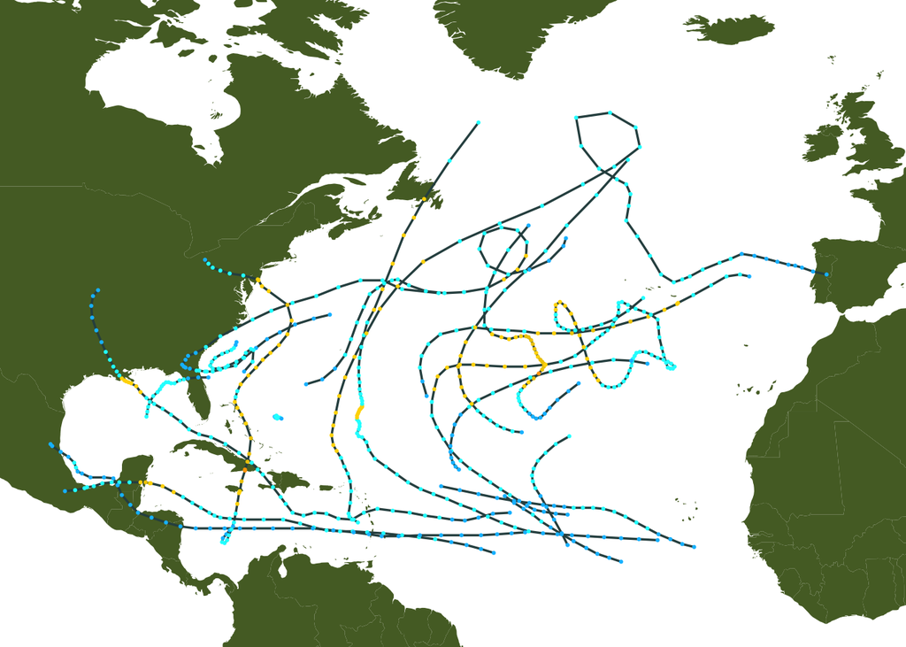

```r
world_map <- map_data("world") # Retrieve the world map data
ibtracs_2012_filtered <- ibtracs_2012[!is.na(ibtracs_2012$WMO_WIND), ] # Remove rows with no WMO_WIND value.

ibtracs_2012_filtered$col <- cut(ibtracs_2012_filtered$WMO_WIND,
                                   breaks = c(0, 33, 63, 82, 95, 112, 136, 300),
                                   labels = c("Depression", "Storm", "Category 1", "Category 2", "Category 3", "Category
                                              4", "Category 5")) # Create a new column categorizing each tropical system

ggplot(ibtracs_2012_filtered, aes(x = LON, y = LAT, group = SID)) +
  geom_polygon(data = world_map, aes(x = long, y = lat, group = group), fill = "darkolivegreen", size = 0.2) +
  geom_path(data = ibtracs_2012_filtered,
            aes(x = LON, y = LAT, group = SID),
            size = 0.6,
            color = "darkslategray") +
  coord_cartesian(xlim=c(-100, -3), ylim=c(5, 65)) +
  geom_point(aes(color=col), size = 0.4) +
  scale_color_manual(values = c("Depression" = "deepskyblue1", "Storm" = "cyan",
                                "Category 1" = "gold1", "Category 2" = "gold2", "Category 3" = "orange1",
                                "Category 4" = "orange3", "Category 5" = "red1")) +
  theme_void() +
  theme(legend.position="none")
```

### C4.b) Did any hurricanes hit the United States? If yes, how many, and which ones?

Yes, two hurricanes, namely, ISAAC and SANDY, did hit the United States.

```r
hur_US <- ibtracs_2012 %>%
  filter(WMO_WIND >= 64, LAT > 19.50139 & LAT < 64.85694 & LON > -161.75583 & LON < -68.01197) %>%
  select(NAME) %>%
  unique()
hur_US # Filter the table so that it only contains hurricanes and ones within the US (based on its latitude and longitude searched up on the web). Then, select the unique name of such hurricanes. From the analysis, we can conclude that yes, two hurricanes, namely, ISAAC and SANDY, did hit the United States.
```

```
##    NAME
## 1 ISAAC
## 8 SANDY
```

# D) Submission

## D.1) Report (Rmd + html)

Please refer to the rmd and html attachments for the code, analysis, and results.

## D.2) Video

Video on analysis of subsections C1 and C2: [Google Drive link to the video](https://drive.google.com/file/d/19m5Cw2IBm49FU2V4LuNNq6hAS5enjdVn/view?usp=sharing)